# Primeira lista de exercícios

Ernani de Souza Cubas Neto

05/06/2022

#### **Com a base de dados “realestateiaa” obter os seguintes resultados com o auxílio do “R”**

#### Carregando as bibliotecas

#### **a) Elaborar o histograma e o boxplot das variáveis “parea e tarea”.**

#### Histograma da variável “parea”

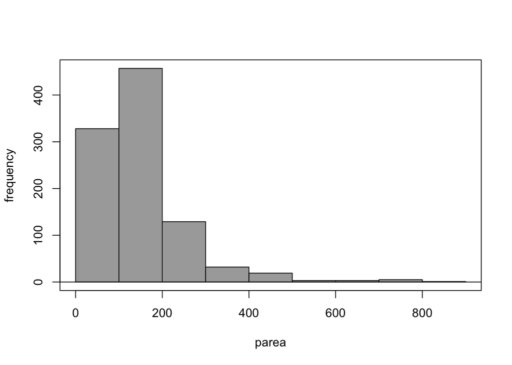

#### Histograma da variável “tarea”

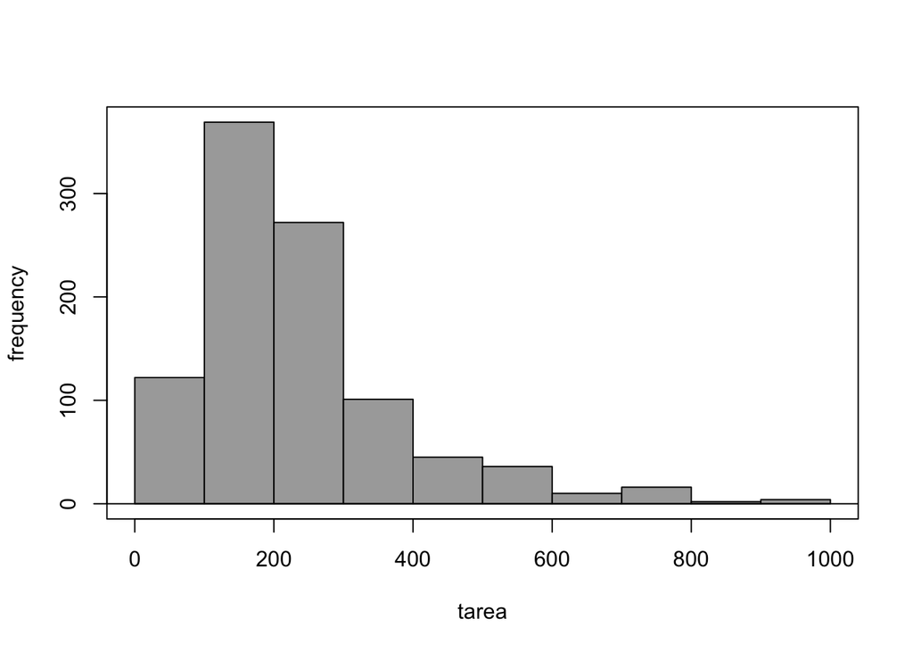

#### Bloxpot da variável “parea”

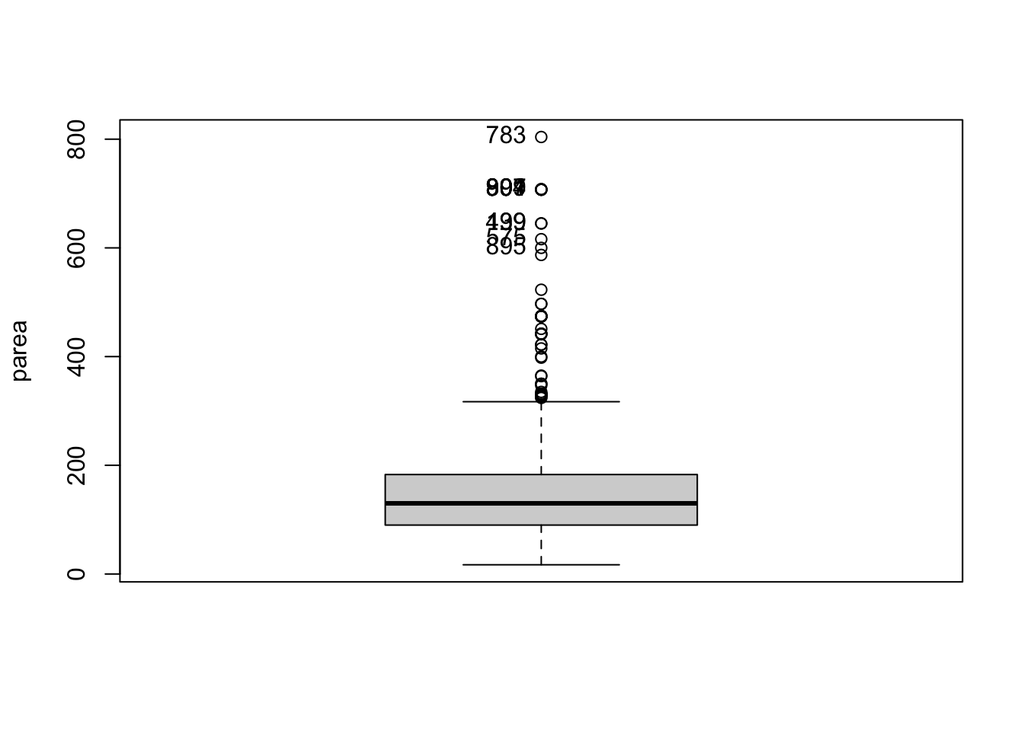

```
##  [1] "783" "891" "904" "897" "901" "909" "139" "499" "575" "895"
```

#### Bloxpot da variável “tarea”

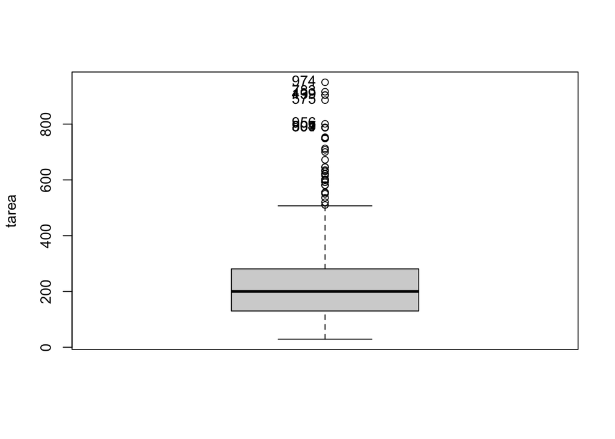

```
##  [1] "974" "783" "139" "499" "575" "956" "891" "904" "909" "897"
```

#### **b) Elaborar a tabela de distribuição de frequências da variável “price” (preço dos imóveis)**

#### Tabela de distribuição de frequências:

```
##        Class limits   f   rf rf(%)  cf  cf(%)
##   [157410,591062.5) 279 0.29 28.56 279  28.56
##  [591062.5,1024715) 288 0.29 29.48 567  58.03
##   [1024715,1458368) 162 0.17 16.58 729  74.62
##   [1458368,1892020) 117 0.12 11.98 846  86.59
##   [1892020,2325673)  53 0.05  5.42 899  92.02
##   [2325673,2759325)  28 0.03  2.87 927  94.88
##   [2759325,3192978)  17 0.02  1.74 944  96.62
##   [3192978,3626630)   8 0.01  0.82 952  97.44
##   [3626630,4060283)  14 0.01  1.43 966  98.87
##   [4060283,4493935)   8 0.01  0.82 974  99.69
##   [4493935,4927588)   3 0.00  0.31 977 100.00
```

*Sobre a resposta:* rf - Frequência Relativa, cf - Frequência Acumulada

#### **c) Para a variável “price” calcular os seguintes indicadores: média; mediana; moda; variância; desvio padrão; CV–Coeficiente de Variação; Quartis; distância interquartílica; percentis.**

| **Indicador** | **Valor** |
| --- | --- |
| Média | 1140123.03 |
| Mediana | 950000 |
| Moda | 850000 - 16 ocorrências |
| Variância | 670486776668.11 |
| Desvio Padrão | 818832.57 |
| CV | 71.82 |
| Quartis | Q1- 550000 Q2- 950000 Q3- 1485000 |
| Dist. Interq. | 935000 |
| Percentis (10%-30%) | 10%- 353000 20%- 490000 30%- 607056.8 |
| Percentis (40%-60%) | 40%- 799400 50%- 950000 60%- 1090000 |
| Percentis (70%-80%) | 70%- 1366000 80%- 1678800 90%- 2123200 |

#### **d) Estimar o intervalo de confiança para a média da variável “price” com 95% de confiança**

```
##
##  One-sample z-Test
##
## data:  realestateiaa$price
## z = 43.522, p-value < 0.00000000000000022
## alternative hypothesis: true mean is not equal to 0
## 95 percent confidence interval:
##  1088778 1191468
## sample estimates:
## mean of x
##   1140123
```

*Sobre a resposta:* A média de valores em “price” varia entre $ 1088778 e $ 1191468, com média de $ 1140123, com 95% de confiança ou 5% de significância. Estatística z = 43.522, ou seja, é maior que a estatística tabeleda, de 1.96, rejeitando-se a hipótese (H0) de que o valor verdadeiro da média é estatisticamente igual a zero.

#### **e) Fazer o teste de diferença entre médias para as variáveis “parea” e “tarea”.**

```
##
##  Two-sample z-Test
##
## data:  realestateiaa$parea and realestateiaa$tarea
## z = -14.151, p-value < 0.00000000000000022
## alternative hypothesis: true difference in means is not equal to 0
## 95 percent confidence interval:
##  -94.09729 -71.20261
## sample estimates:
## mean of x mean of y
##  152.9867  235.6366
```

#### **f) Fazer o teste de diferença entre variâncias para as variáveis “parea” e “tarea”.**

```
##
##  F test to compare two variances
##
## data:  realestateiaa$parea and realestateiaa$tarea
## F = 0.43855, num df = 976, denom df = 976, p-value <
## 0.00000000000000022
## alternative hypothesis: true ratio of variances is not equal to 1
## 95 percent confidence interval:
##  0.3868074 0.4972143
## sample estimates:
## ratio of variances
##          0.4385501
```

*Sobre a resposta:* A razão de variância é de 0.4385501 e a estatística F = 0.43855 com 976 graus de liberdade no numerador e denominador. Como o valor de F não está entre os valores tabelados 0.900007 e 1.111102 (encontrados pela função qf(0.95,976,976) e 1/qf(0.95,976,976)), as variâncias não são estatísticamente iguais.

#### **g) Fazer o Teste de Wilcoxon-Mann-Whitney para amostras independentes para as variáveis “parea” e “tarea”.**

```
##
##  Wilcoxon rank sum test with continuity correction
##
## data:  realestateiaa$parea and realestateiaa$tarea
## W = 287419, p-value < 0.00000000000000022
## alternative hypothesis: true location shift is not equal to 0
```

#### **h) Fazer 2 testes de normalidade (a sua escolha) para a variável “price”.**

#### Teste de normalidade de Kolmogorov-Smirnov

```
##
##  Lilliefors (Kolmogorov-Smirnov) normality test
##
## data:  price
## D = 0.14486, p-value < 0.00000000000000022
```

*Sobre a resposta:* Valor calculado de D = 0.14486 e p-value menor que 0.05, significando que não existe normalidade da amostra

#### Teste de normalidade de Anderson-Darling

```
##
##  Anderson-Darling normality test
##
## data:  realestateiaa$price
## A = 35.862, p-value < 0.00000000000000022
```

*Sobre a resposta:* Como p-value é menor que 0.05 rejeita-se a hipótese de normalidade da variável